# Statistisk Inferens: Sandsynlighedsfordelinger og konfidensintervaller

Metode 1 F25 #7

Søren Damsbo-Svendsen

26. marts 2025

## Temaer

Ugen burde måske have heddet **“Statistisk inferens”**

- Hvordan vi bruger det vi *ved* (stikprøve/data) til at drage konklusioner om det vi *ikke* kender → populationen/“sandheden”
- Sandsynlighed
- Sandsynlighedsfordelinger, primært **normalfordelingen**
- *Stikprøvemålsfordeling* og **standardfejl**
  - *Den Centrale Grænseværdisætning*
- Udregning og fortolkning af **konﬁdensintervaller**

## Hovedpointer

1. Når vi arbejder med stikprøver, er der altid usikkerhed
2. Vi kan kvantificere denne usikkerhed pba. teori om *stikprøvemålsfordelinger*
3. Ofte tør vi antage, at stikprøvemålsfordelingen er *normalfordelt* → gør livet lettere
4. Vi kan fx tilføje *konfidensintervaller* til vores statistikker (gennemsnit mv.)
   - Så kan vi kommunikere vores bedste gæt/beskrivelse af et fænomen OG (u)sikkerheden i vores gæt/beskrivelse
5. Basal statistisk inferens, som vi lærer i denne uge, er fundamentet for stort set *al kvantitativ metode*

## Plan for forelæsningen

1. Sandsynlighed
2. Sandsynlighedsfordelinger
3. Normalfordelingen og *z-værdier*
4. Stikprøver, gennemsnit og stikprøvemålsfordelinger
5. *Den Centrale Grænseværdisætning (Central Limit Theorem, CLT)*
6. Standardfejl
7. Konfidensintervaller

# Sandsynlighed

## Sandsynlighed

- **Udfald** af en variabel, *X*: Den værdi X får, når den realiseres (fx terning → 2)
- **Mulige udfald** (udfaldsrum): Alle værdier, som X *kunne* få (fx terning → 1,2,3,4,5,6)
- **Sandsynligheden** for et udfald:
  - andelen af alle observationer, der har et bestemt udfald, når X observeres/realiseres MANGE gange (uendeligt)
- **Terningekast:**
  - 6 mulige udfald med samme sandsynlighed
  - Sandsynligheden for at slå 6: $Pr = 1/6 ≈ .166$
  - Ved 1.000.000 slag forventer vi meget tæt ved 166.667 (17%) 6’ere
  - Ved 3 slag kan alting ske (ellers var Yatzy ikke sjovt)
  - Andelen af 6’ere konvergerer mod $1/6$ når antallet af slag → $∞$

## Sandsynlighedsfordelinger

- En sandsynlighedsfordeling beskriver sandsynligheden for alle mulige udfald på en variabel, *X*
- Ikke det samme som fordeling af en variabel, men alligevel næsten
  - samme princip, blot sandsynligheder for udfald (hypotetisk) frem for observerede udfald (realiseret)
- Vi kan beregne et gennemsnit for en sandsynlighedsfordeling præcis som for en talrække/alm. variabel
  - og beskrive den med andre statistikker fra deskriptiv *stats*: standardafvigelse, median, min/max osv.
  - gennemsnittet i en sandsynlighedsfordeling kaldes også den **forventede værdi**

## Sandsynlighedsfordelinger

- *X* er diskret → diskret sandsynlighedsfordeling
  - kategorisk/ordinal/binær
  - visualisering: heltal på x-aksen med søjler (fx geom_histogram)
- *X* er kontinuert → kontinuert sandsynlighedsfordeling
  - intervalskaleret
  - visualisering: kontinuum på x-aksen med kurve (fx geom_density)

## Diskrete sandsynlighedsfordelinger

- Terningkast følger en diskret sandsynlighedsfordeling
- Gennemsnit:
  - summen af mulige udfald ganget med deres sandsynligheder
  - $µ = ∑ yPr(y)$
- fx for en terning:, $µ = 1 * 1/6 + 2 * 1/6 + ... + 6 * 1/6 = \frac{21}{6} = 3.5$
  - → midtpunktet mellem 1 og 6
- Møntkast (binær) følger også en diskret sandsynlighedsfordeling: …

## Plat og krone: antal *krone* ved 1 møntkast

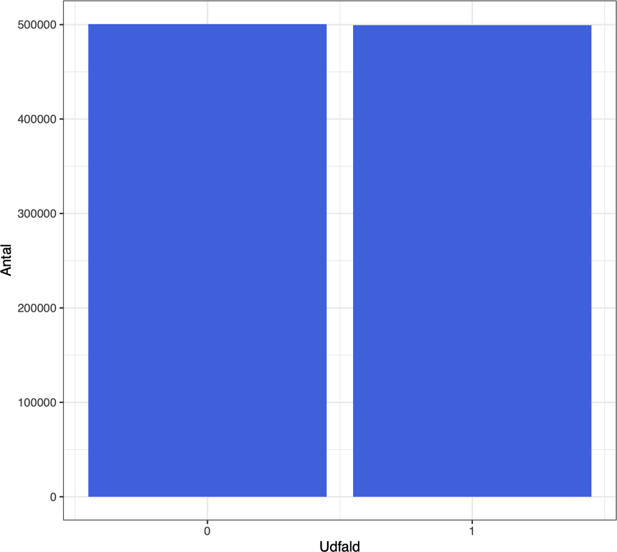

Frederik Hjorth

## Plat og krone: antal *krone* ved 2 møntkast

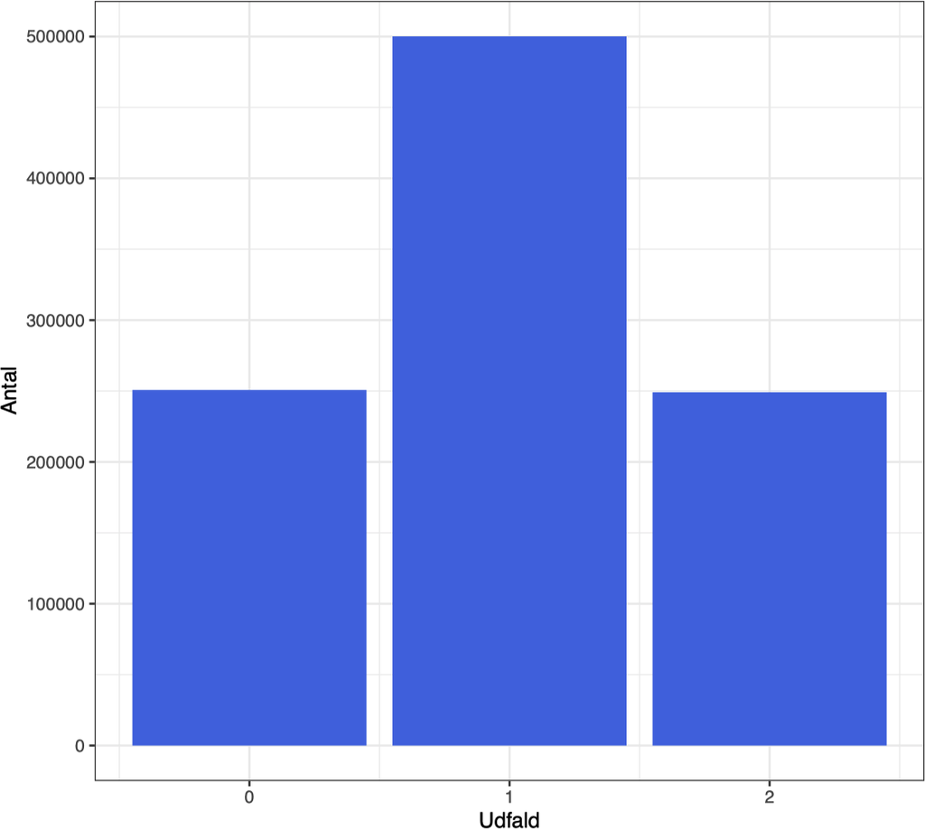

Frederik Hjorth

## Plat og krone: antal *krone* ved 3 møntkast

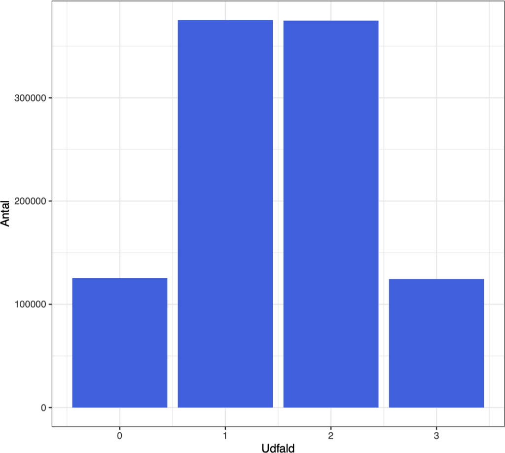

Frederik Hjorth

## Plat og krone: antal *krone* ved 4 møntkast

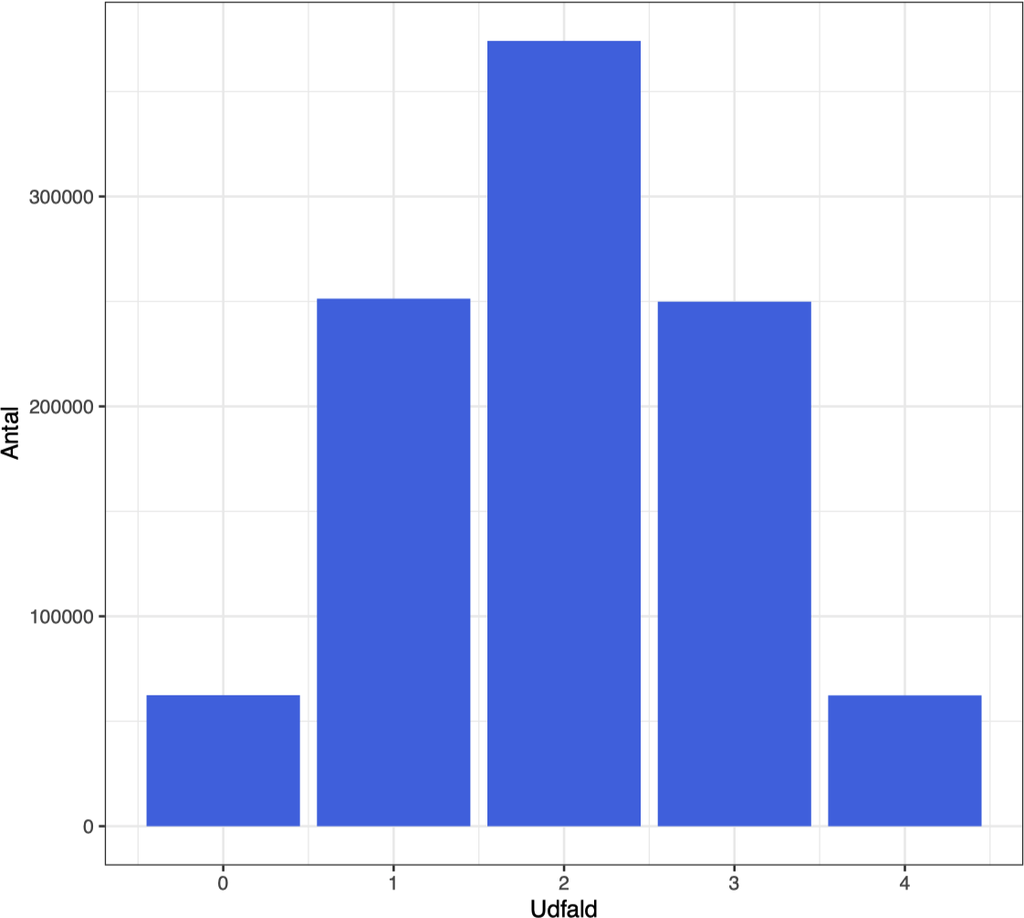

Frederik Hjorth

## Plat og krone: antal *krone* ved 5 møntkast

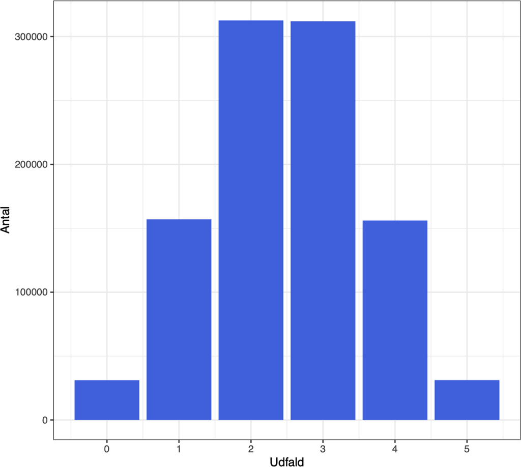

Frederik Hjorth

## Plat og krone: antal *krone* ved 6 møntkast

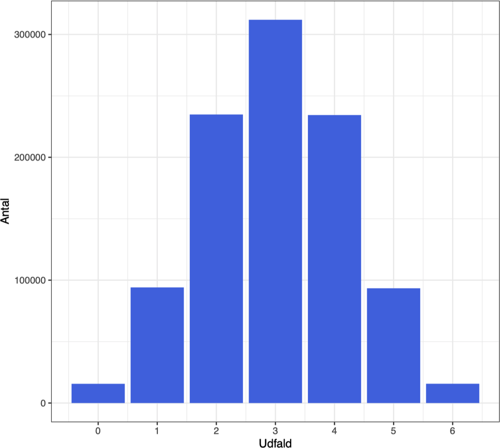

Frederik Hjorth

## Kontinuerte sandsynlighedsfordelinger

- Kontinuerte variable har **uendelige mulige udfald**
- Derfor kan vi ikke tilskrive hver eksakt værdi en sandsynlighed
- i stedet:
  - sandsynlighed for **intervaller af værdier/udfald**
  - hvad er sandsynligheden for at det bliver 1-2 grader varmere i morgen end normalen?
  - frem for hvad er sandsynligheden for, at det bliver 1.521599215 grader varmere i morgen
  - eller 1.521521*6*, 1.521521*7*, 1.521521*8* osv. osv.
- Sandsynligheden er kan beskrives med **arealet under grafen** (sandsynlighedsfordelingen), som ligger i det pågældende interval

# Normalfordelingen

## Normalfordelingen

```r
tibble(x = -4:4) |>
  ggplot() +
  aes(x = x) +
  stat_function(fun = dnorm, args = list(mean = 0, sd = 1))  +
  scale_x_continuous(breaks = -4:4) +
  labs(x = "z", y = "P")
```

[output not shown]

- “Bell-shaped”
- Symmetrisk omkring gennemsnittet
- ¿ **Hvad er medianen? Hvad er typetallet?** ?
- Ikke skæv
- Asymptotisk i halerne (uendelig)

## Normalfordelingen

> “some probability distributions are important because they approximate well the distributions of variables in the real world”
- Eksempler på (approksimativt) **normalfordelte fænomener:**
  - *størrelse mv. på dyr og planter* (vægten af fisk, højden på mennesker)
  - *mentale attributter* (IQ, reaktionstider, testscorer)
  - *miljøfænomener* (temperaturer ift. normal)
  - *adfærd* (antal apps)
- Alternative **fordelinger:**
  - *uniform* (samme sandsynlighed, fx terning)
  - *binomial* (andel af “successer”, fx 6’ere)
  - *t-fordeling* (meget lig normal)

## 68-95-99-(tommelfinger)reglen:

> Andelen af observationer/sandsynlighedsmassen i normalfordelingen, der ligger inden for 1, 2, 3 standardafvigelser $σ$ fra fordelingens gennemsnit $µ$:
- **68 %** ligger inden for $µ ± 1σ$
- **95 %** ligger inden for $µ ± 2σ$
- **99 %** ligger inden for $µ ± 3σ$

**Kode**

```r
# beregning af nøjagtige værdier i R
pnorm(1) - pnorm(-1)
## [1] 0.6826895
pnorm(2) - pnorm(-2)
## [1] 0.9544997
pnorm(3) - pnorm(-3)
## [1] 0.9973002
```

## 68-95-99-(tommelfinger)reglen:

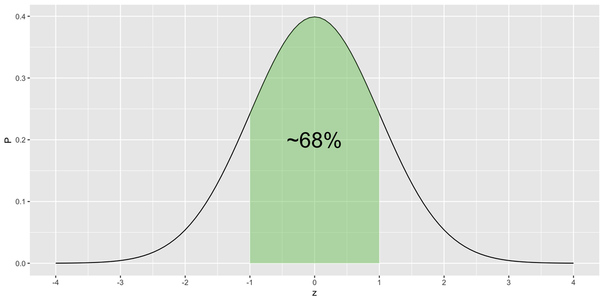

Normalfordelingen (gns. = 0, std.afv. = 1) – 68% af normalfordelingen

```r
tibble(x = -4:4) |>
  ggplot() +
  aes(x = x) +
  stat_function(fun = dnorm, args = list(mean = 0, sd = 1))  +
  stat_function(fun = dnorm, args = list(mean = 0, sd = 1), geom = "area", xlim = c(-1, 1), fill = "#84CA72", alpha = .5) +
  annotate("text", x = 0, y = 0.2, label = "~68%", size = 9) +
  scale_x_continuous(breaks = -4:4) +
  labs(x = "z", y = "P")
```

## 68-95-99-(tommelfinger)reglen:

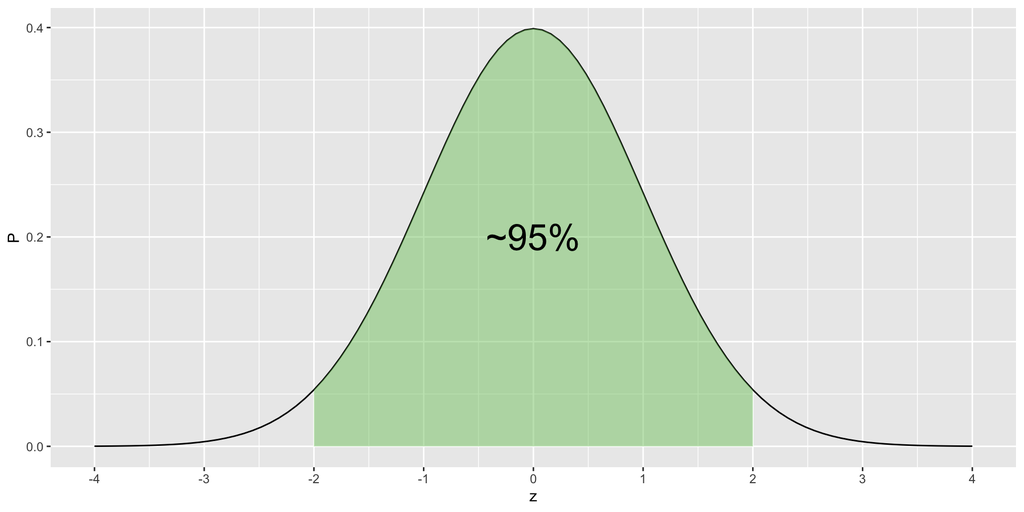

Normalfordelingen (gns. = 0, std.afv. = 1) – 95% af normalfordelingen

```r
tibble(x = -4:4) |>
  ggplot() +
  aes(x = x) +
  stat_function(fun = dnorm, args = list(mean = 0, sd = 1))  +
  stat_function(fun = dnorm, args = list(mean = 0, sd = 1), geom = "area", xlim = c(-2, 2), fill = "#84CA72", alpha = .5) +
  annotate("text", x = 0, y = 0.2, label = "~95%", size = 9) +
  scale_x_continuous(breaks = -4:4) +
  labs(x = "z", y = "P")
```

## 68-95-99-(tommelfinger)reglen:

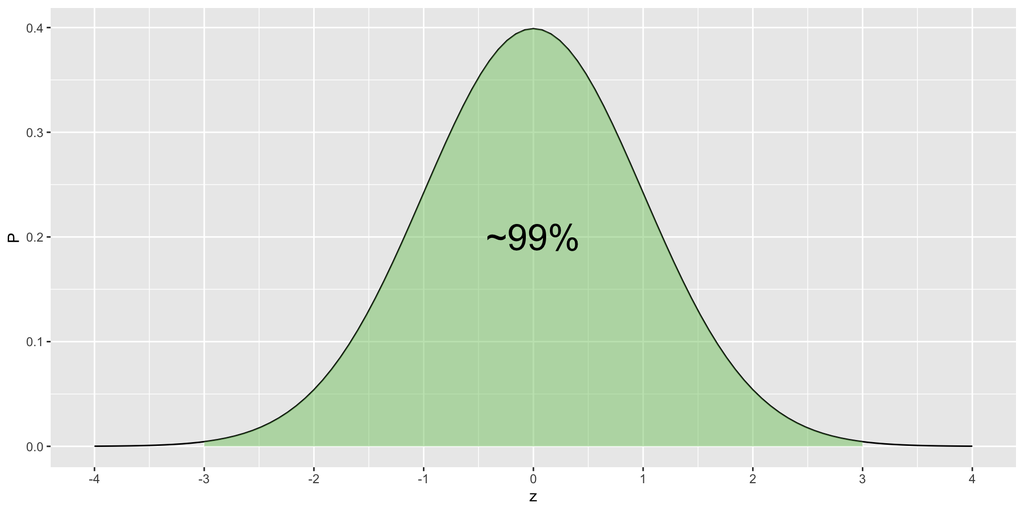

Normalfordelingen (gns. = 0, std.afv. = 1) – 99% af normalfordelingen

```r
tibble(x = -4:4) |>
  ggplot() +
  aes(x = x) +
  stat_function(fun = dnorm, args = list(mean = 0, sd = 1))  +
  stat_function(fun = dnorm, args = list(mean = 0, sd = 1), geom = "area", xlim = c(-3, 3), fill = "#84CA72", alpha = .5) +
  annotate("text", x = 0, y = 0.2, label = "~99%", size = 9) +
  scale_x_continuous(breaks = -4:4) +
  labs(x = "z", y = "P")
```

## 68-95-99-(tommelfinger)reglen:

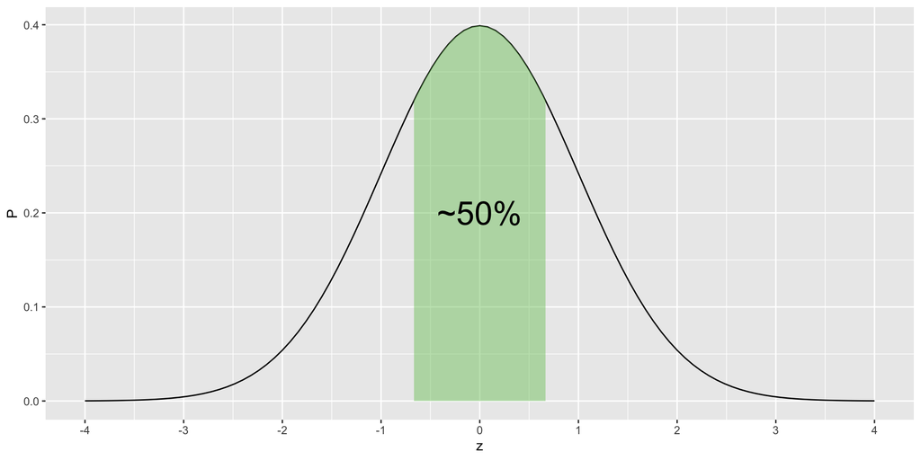

Normalfordelingen (gns. = 0, std.afv. = 1) – 50% af normalfordelingen

```r
tibble(x = -4:4) |>
  ggplot() +
  aes(x = x) +
  stat_function(fun = dnorm, args = list(mean = 0, sd = 1))  +
  stat_function(fun = dnorm, args = list(mean = 0, sd = 1), geom = "area", xlim = c(-2/3, 2/3), fill = "#84CA72", alpha = .5) +
  annotate("text", x = 0, y = 0.2, label = "~50%", size = 9) +
  scale_x_continuous(breaks = -4:4) +
  labs(x = "z", y = "P")
```

## 68-95-99-(tommelfinger)reglen:

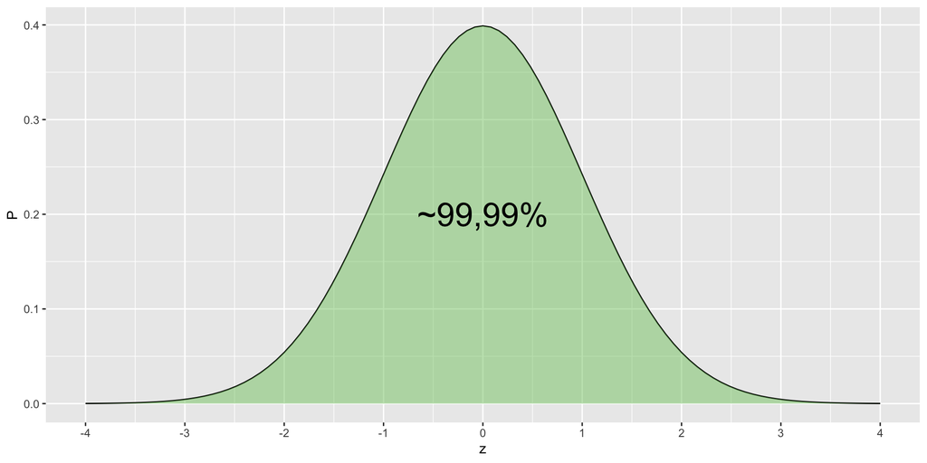

Normalfordelingen (gns. = 0, std.afv. = 1) – 99,99% af normalfordelingen

[figure not shown]

```r
tibble(x = -4:4) |>
  ggplot() +
  aes(x = x) +
  stat_function(fun = dnorm, args = list(mean = 0, sd = 1))  +
  stat_function(fun = dnorm, args = list(mean = 0, sd = 1), geom = "area", xlim = c(-4, 4), fill = "#84CA72", alpha = .5) +
  annotate("text", x = 0, y = 0.2, label = "~99,99%", size = 9) +
  scale_x_continuous(breaks = -4:4) +
  labs(x = "z", y = "P")
```

## Eksempel: IQ

- **IQ** i befolkningen er approks. normalfordelt
  - $µ ≈ 100$
  - $σ ≈ 15$
- 68-95-99-reglen → 95 % af os har en IQ på $100 ± 2 × 15$
  - dvs. mellem 70 og 130
- Sandsynligheden for at have en **IQ højere end 130** = $\frac{1 − 0,95}{2} = 0,025$
  - dvs. 2,5 %
  - samme for Pr(under 70) → 2,5 %

## Z-værdier

- Afvigelser fra gennemsnittet i en normalfordeling kan beregnes som en **z-værdi**
- Alle z-værdier har en sandsynlighed → Pr(*z* eller derover/derunder)
- *z* er observationens afvigelse fra variablens gennemsnit udtrykt i antal standardafvigelser
- $z = \frac{y − µ}{\sigma}$
- Givet en normalfordeling med $µ = 100$ og $\sigma = 15$ har:
  - scoren *130* z-værdien $\frac{130 - 100}{15} = 2$
  - scoren *160* z-værdien $\frac{160 - 100}{15} = 4$
- Omskalerer værdierne, så de matcher *standardnormalfordelingen* ($µ = 0$, $\sigma = 1$)
- Alle intervalskalerede variable kan oversættes til z-værdier → kaldes **standardisering**

## Standardisering af variabel i R

```r
# lav en variabel, der går fra 0 til 10
tibble(var = 0:10) |>
  # standardisér
  mutate(gns = mean(var),
         sd = sd(var),
         z_manu = (var - gns) / sd,
         z_auto = as.double(scale(var))) |>
  kable(digits = 2)
```

| var | gns | sd | z_manu | z_auto |
| --- | --- | --- | --- | --- |
| 0 | 5 | 3.32 | -1.51 | -1.51 |
| 1 | 5 | 3.32 | -1.21 | -1.21 |
| 2 | 5 | 3.32 | -0.90 | -0.90 |
| 3 | 5 | 3.32 | -0.60 | -0.60 |
| 4 | 5 | 3.32 | -0.30 | -0.30 |
| 5 | 5 | 3.32 | 0.00 | 0.00 |
| 6 | 5 | 3.32 | 0.30 | 0.30 |
| 7 | 5 | 3.32 | 0.60 | 0.60 |
| 8 | 5 | 3.32 | 0.90 | 0.90 |
| 9 | 5 | 3.32 | 1.21 | 1.21 |
| 10 | 5 | 3.32 | 1.51 | 1.51 |

## Standardisering af variabel i R

```r
# udvælg aldersvariablen i valgundersøgelsen
 vu |>
  select(alder = alder_på_valgdag) |>
  filter(!is.na(alder)) |>
  # standardisér
  mutate(gns = mean(alder),
         sd = sd(alder),
         z_manu = (alder - gns) / sd,
         z_auto = as.double(scale(alder))) |>
  sample_n(11) |>
  arrange(alder) |>
  kable(digits = 2)
```

| alder | gns | sd | z_manu | z_auto |
| --- | --- | --- | --- | --- |
| 26 | 52.95 | 18.47 | -1.46 | -1.46 |
| 30 | 52.95 | 18.47 | -1.24 | -1.24 |
| 33 | 52.95 | 18.47 | -1.08 | -1.08 |
| 38 | 52.95 | 18.47 | -0.81 | -0.81 |
| 46 | 52.95 | 18.47 | -0.38 | -0.38 |
| 50 | 52.95 | 18.47 | -0.16 | -0.16 |
| 67 | 52.95 | 18.47 | 0.76 | 0.76 |
| 68 | 52.95 | 18.47 | 0.81 | 0.81 |
| 75 | 52.95 | 18.47 | 1.19 | 1.19 |
| 76 | 52.95 | 18.47 | 1.25 | 1.25 |
| 83 | 52.95 | 18.47 | 1.63 | 1.63 |

## Z-værdier i R

- R kan fortælle os, hvor ekstrem en værdi er baseret på dens *z-værdi*:
  - `pnorm(1.33)`: 0.9082409
  - → hvor meget af normalfordelingen har en *mindre* z-værdi, end den angivne (arealet under kurven)
  - ~91 % har en z-værdi under 1.33
- Vi kan tilsvarende udregne, hvor meget der har en *højere* z-værdi
  - `1 - pnorm(1.33):` 0.0917591
  - ~9 % har en z-værdi over 1.33

## Z-værdier i R

## Omvendt: fra sandsynlighed til z-værdi

- R kan også beregne, hvilken z-værdi der svarer til hvilken (kumulerede) sandsynlighed
- Fx hvor uklog man kan være og stadig være blandt de klogeste 10 %?
  - m.a.o.: hvad er den *mindste z-værdi* i den højeste *decil* (tiendedel) af normalfordelingen?
- `qnorm(p)` returnerer z-værdien for en given andel/sandsynlighed, *p*, i standardnormalfordelingen

```r
qnorm(.9) # 90%
```

```
[1] 1.281552
```

- 90 % har $z < 1.28$
- 10 % har $z > 1.28$
- Hvis din IQ svarer til $z = 1.28$, er din *ikke-standardiserede IQ-score:*
  - → $100 + 1.28 * 15 ≈ 119$

## Snak sammen

> Den gennemsnitlige testscore i en klasse er 60 med standardafvigelsen 10. *Du scorer 75.* Hvad er z-værdien for denne observation?

$z = \frac{y − µ}{\sigma}$

1. 0.74
2. 15
3. 1.5
4. Kan ikke udregnes pba. informationen

Frederik Hjorth

## Snak sammen

> Er du så kommet i top 10 i klassen?

```r
pnorm(1.5)
```

```
[1] 0.9331928
```

# Stikprøvemålsfordelingen

## Stikprøvemålsfordelingen

- På engelsk “sampling distribution”
- Teori om vores samplingprocedure
- “Stikprøvemål” kan være mange forskellige statistikker (beregnet på stikprøvedata) → vi fokuserer på gennemsnit/andel
  - dvs. at stikprøven opsummeres som udgangspunkt i ét enkelt tal → gennemsnittet af en variabel
  - fx gennemsnitlig *højre-venstre-placering* eller *alder*
- **Stikprøvemålsfordelingen** en teoretisk abstraktion, som vi ikke kan observere
  - vi har (som regel) blot *ét enkelt gennemsnit*
  - men havde vi fortsat med at tage *nye stikprøver*, ville vi få flere og flere
  - hvordan ser sandsynlighedsfordelingen for mulige stikprøvemål ud?
  - det afhænger af (1) stikprøvestørrelsen og (2) typen af stikprøvemål

## Tre typer fordelinger

1. Populationsfordeling – en variabel
2. Stikprøvefordeling (sample distribution) – en variabel
3. Stikprøve*måls*fordeling (*sampling* distribution) – gennemsnit af en variabel

#### (1) Populationsfordeling

- fordeling af en variabel i **populationen**
- fx **befolkningens alder** (fordeling af værdier: 0-122)

#### (2) Stikprøvefordeling

- fordeling af *samme variabel* i en enkelt (tilfældig) **stikprøve** fra populationen
- *n* (stikprøve)  
  < *N* (population)
- alder i **stikprøven** (fordeling af værdier: 0-122 – *ligner* lidt populationen, men er ikke magen til)

#### (3) Stikprøvemålsfordeling

- sandsynlighedsfordeling for (fx) mulige *gennemsnit af en variabel i et undeligt antal stikprøver*
- stikprøver med *n* enheder (fast)
- fordeling af **mulige gennemsnitsaldre**
- fortæller os noget om forholdet mellem (1) og (2)

## Population: alder (simuleret)

**Kode**

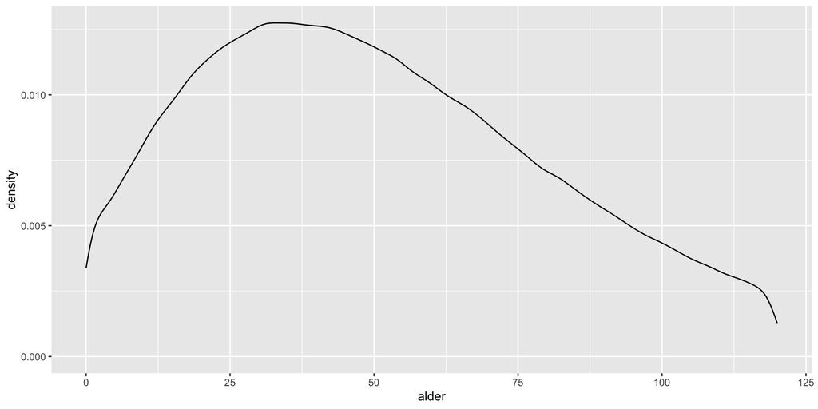

Populationsfordeling (simuleret)

```r
set.seed(50)
pop <- tibble(alder = rnorm(n = 1000000,
                            mean = 50,
                            sd = 18)) |>
  mutate(alder = alder^2 / 50) |>
  filter(alder < 120)

pop |>
  ggplot() +
  aes(x = alder) +
  geom_density()
```

- Simuleret **populationens alder**
- $µ ≈ 50$ år, $σ ≈ 30$ år
- **Husk at vi ikke observerer hele denne fordeling!**
  - derfor vi laver *stikprøver*
  - men vi kan altid *forestille* os populationen

## Stikprøve 1

**Kode**

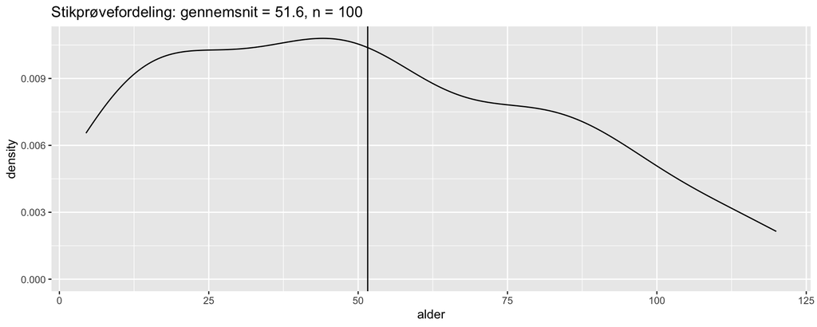

```r
sample1 <- pop |> # tilfældig stikprøve (n = 100)
  sample_n(100)

sample1 |>
  ggplot() +
  aes(x = alder) +
  geom_density() +
  geom_vline(xintercept = mean(sample1$alder)) +
  labs(title = paste0("Stikprøvefordeling: gennemsnit = ", round(mean(sample1$alder), 1), ", n = 100"))
```

## Stikprøve 2

**Kode**

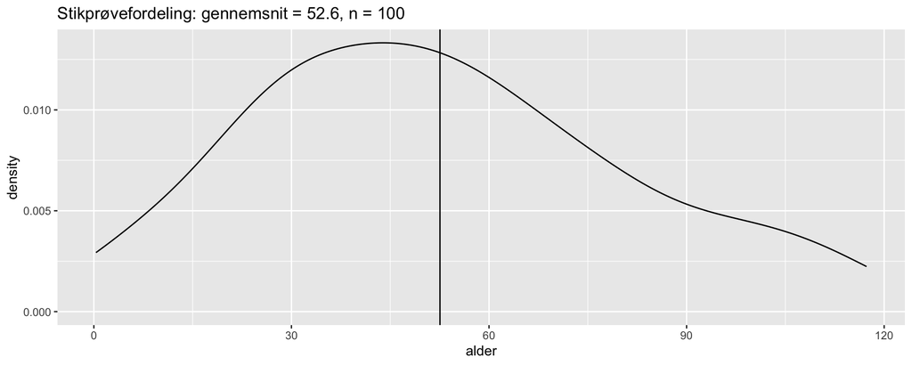

```r
sample2 <- pop |> # tilfældig stikprøve (n = 100)
  sample_n(100)

sample2 |>
  ggplot() +
  aes(x = alder) +
  geom_density() +
  geom_vline(xintercept = mean(sample2$alder)) +
  labs(title = paste0("Stikprøvefordeling: gennemsnit = ", round(mean(sample2$alder), 1), ", n = 100"))
```

## Stikprøve 3

**Kode**

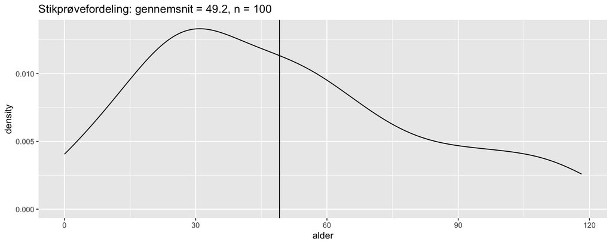

```r
sample3 <- pop |> # tilfældig stikprøve (n = 100)
  sample_n(100)

sample3 |>
  ggplot() +
  aes(x = alder) +
  geom_density() +
  geom_vline(xintercept = mean(sample3$alder)) +
  labs(title = paste0("Stikprøvefordeling: gennemsnit = ", round(mean(sample3$alder), 1), ", n = 100"))
```

## Stikprøve 4

**Kode**

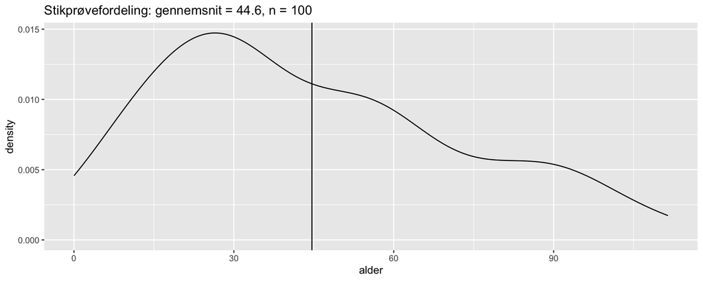

```r
sample4 <- pop |> # tilfældig stikprøve (n = 100)
  sample_n(100)

sample4 |>
  ggplot() +
  aes(x = alder) +
  geom_density() +
  geom_vline(xintercept = mean(sample4$alder)) +
  labs(title = paste0("Stikprøvefordeling: gennemsnit = ", round(mean(sample4$alder), 1), ", n = 100"))
```

## Stikprøve 5

**Kode**

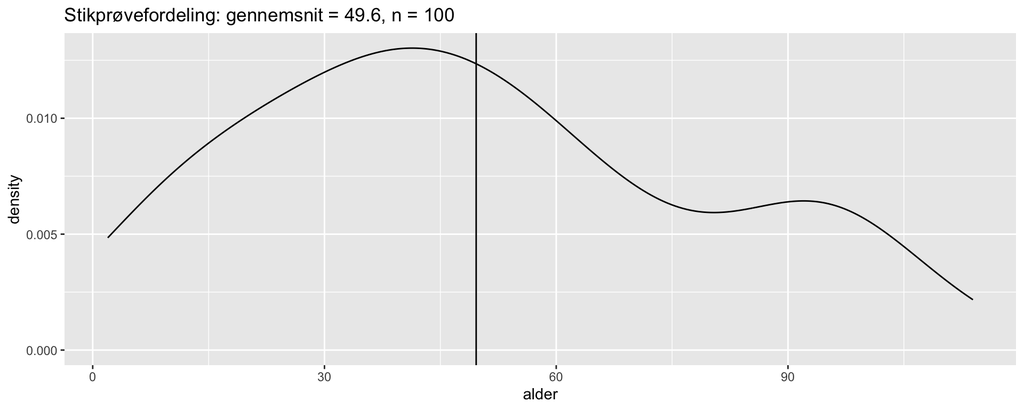

```r
sample5 <- pop |> # tilfældig stikprøve (n = 100)
  sample_n(100)

sample5 |>
  ggplot() +
  aes(x = alder) +
  geom_density() +
  geom_vline(xintercept = mean(sample5$alder)) +
  labs(title = paste0("Stikprøvefordeling: gennemsnit = ", round(mean(sample5$alder), 1), ", n = 100"))
```

## Gennemsnitsalder

- Populationsgennemsnit: ca. 50 år (ukendt parameter)
- *Stikprøvegennemsnit (opsummering):*
  - 1 ≈ 52
  - 2 ≈ 53
  - 3 ≈ 49
  - 4 ≈ 45
  - 5 ≈ 50
  - . . .
  - 9999 ≈ ???
- Lad os prøve at udtage MANGE stikprøver i R…

## Gentag sampling 5 gange og plot

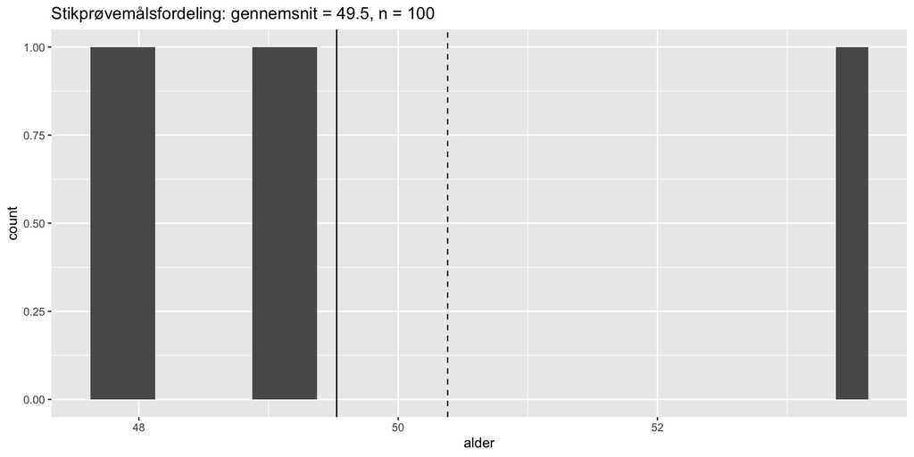

Stikprøvemålsfordeling (gennemsnit) – sampling gentaget 5 gange

```r
gns_list <- map(1:5,
    ~ pop |>
      sample_n(100) |>
      pull(alder) |>
      mean())

gns <- tibble(alder = unlist(gns_list))

gns |>
  ggplot() +
  aes(x = alder) +
  geom_histogram(binwidth = .25) +
  geom_vline(xintercept = mean(gns$alder)) +
  geom_vline(xintercept = mean(pop$alder), linetype = "dashed") +
  labs(title = paste0("Stikprøvemålsfordeling: gennemsnit = ", round(mean(gns$alder), 1), ", n = 100"))
```

## Gentag sampling 30 gange og plot

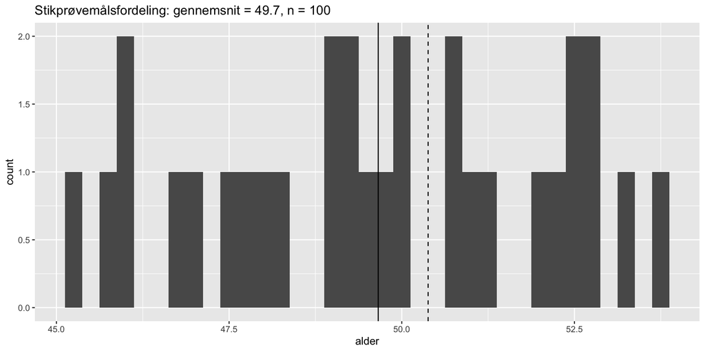

Stikprøvemålsfordeling (gennemsnit) – sampling gentaget 30 gange

```r
gns_list <- map(1:30,
    ~ pop |>
      sample_n(100) |>
      pull(alder) |>
      mean())

gns <- tibble(alder = unlist(gns_list))

gns |>
  ggplot() +
  aes(x = alder) +
  geom_histogram(binwidth = .25) +
  geom_vline(xintercept = mean(gns$alder)) +
  geom_vline(xintercept = mean(pop$alder), linetype = "dashed") +
  labs(title = paste0("Stikprøvemålsfordeling: gennemsnit = ", round(mean(gns$alder), 1), ", n = 100"))
```

## Gentag sampling 300 gange og plot

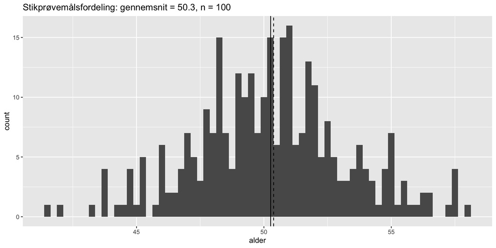

Stikprøvemålsfordeling (gennemsnit) – sampling gentaget 300 gange

```r
gns_list <- map(1:300,
    ~ pop |>
      sample_n(100) |>
      pull(alder) |>
      mean())

gns <- tibble(alder = unlist(gns_list))

gns |>
  ggplot() +
  aes(x = alder) +
  geom_histogram(binwidth = .25) +
  geom_vline(xintercept = mean(gns$alder)) +
  geom_vline(xintercept = mean(pop$alder), linetype = "dashed") +
  labs(title = paste0("Stikprøvemålsfordeling: gennemsnit = ", round(mean(gns$alder), 1), ", n = 100"))
```

## Gentag sampling 3000 gange og plot

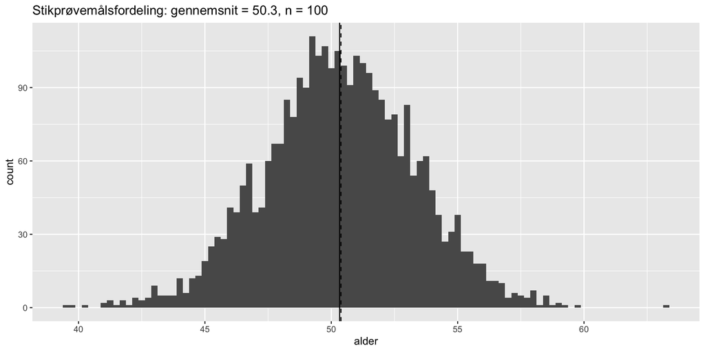

Stikprøvemålsfordeling (gennemsnit) – sampling gentaget 3000 gange

```r
gns_list <- map(1:3000,
    ~ pop |>
      sample_n(100) |>
      pull(alder) |>
      mean())

gns <- tibble(alder = unlist(gns_list))

gns |>
  ggplot() +
  aes(x = alder) +
  geom_histogram(binwidth = .25) +
  geom_vline(xintercept = mean(gns$alder)) +
  geom_vline(xintercept = mean(pop$alder), linetype = "dashed") +
  labs(title = paste0("Stikprøvemålsfordeling: gennemsnit = ", round(mean(gns$alder), 1), ", n = 100"))
```

**Kode**

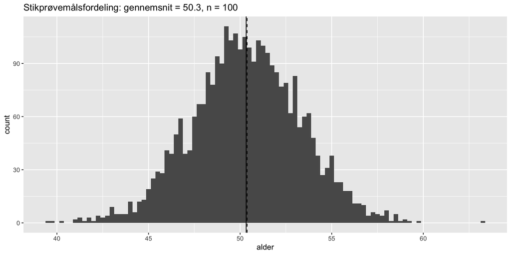

Stikprøvemålsfordeling (gennemsnit) – sampling gentaget 3000 gange

```r
gns |>
  ggplot() +
  aes(x = alder) +
  geom_histogram(binwidth = .25) +
  geom_vline(xintercept = mean(gns$alder)) +
  geom_vline(xintercept = mean(pop$alder), linetype = "dashed") +
  labs(title = paste0("Stikprøvemålsfordeling: gennemsnit = ", round(mean(gns$alder), 1), ", n = 100"))
```

# Det leder os frem til magien i statistisk inferens

## Den Centrale Grænseværdisætning (*Central Limit Theorem*, CLT)

Uanset hvordan variablen er fordelt i **populationen**,og  
uanset hvordan variablen er fordelt i **stikprøven**, gælder det at

## Den Centrale Grænseværdisætning (*Central Limit Theorem*, CLT)

Uanset hvordan variablen er fordelt i **populationen**,og  
uanset hvordan variablen er fordelt i **stikprøven**, gælder det at

> Stikprøvemålsfordelingen for stikprøvens gennemsnit er **altid (approks.) normalfordelt**, når stikprøven er stor<sup>1</sup>
- “Stor” stikprøve: *n > 30* (tommelfingerregel)
- **CLT** er en vigtig statistisk/matematisk “opdagelse”
  - gælder *i teorien* for “an inﬁnite number of random samples” (asymptotisk)
  - gælder *i praksis* meget ofte
  - frigør os fra en masse bøvl og krævende antagelser
[^1]: For random sampling with a large sample size *n*, the sampling distribution of the sample mean $\bar{y}$ is approximately a normal distribution” (Agresti & Finlay 2014: 93).

## Den Centrale Grænseværdisætning (*Central Limit Theorem*, CLT)

Uanset hvordan variablen er fordelt i **populationen**,og  
uanset hvordan variablen er fordelt i **stikprøven**, gælder det at

> Stikprøvemålsfordelingen for stikprøvens gennemsnit er **altid (approks.) normalfordelt**, når stikprøven er stor
- **CLT** gælder for mange “stikprøvemål”:
  - *gennemsnit* (kontinuert variabel)
  - *andel* (gennemsnit af *binær* variabel)
  - *sum*
  - *forskel* mellem to grupper (samme variabel) eller mellem to variable
  - *lineær sammenhæng* mellem to variable (korrelations-/regressionskoefficienter)
- Men ikke alle stikprøvemål (fx medianen)

## Illustration af CLT

→ http://mfviz.com/central-limit/

## Standardfejl

- **Stikprøvemålsfordelingen for gennemsnittet** er normalfordelt (pga. CLT)
- Denne viden kan bruges til at kvantificere afstanden mellem stikprøver og den “sande” værdi
- Til dette skal vi bruge stikprøvemålsfordelingens **standardafvigelse**
  - hvor langt falder stikprøvegennemsnittene typisk fra det sande populationsgennemsnit?
  - hvor stor er *spredningen* i mulige stikprøvegennemsnit?
- Denne kaldes **standardfejlen:**
  - $se = \frac {\sigma} {\sqrt{n}}$,  
    hvor $\sigma$ er std.afv. i populationen, og *n* er stikprøvestørrelsen

## Standardfejl: alder

- Alder (populationen):
  - $µ$ ≈ 50 år, $σ$ ≈ 30 år
- Alder (stikprøve 1, *n* = 100)
  - $\bar{y}$ ≈ 52 år, $s$ ≈ 32 år
- $se = \frac {\sigma} {\sqrt{n}} = ???$
- I praksis kender vi ikke $\sigma$ (std.afv. i *populationen*)
  - så vi *estimerer* den som *s* (std.afv. i *stikprøven*) → giver en smule ekstra usikkerhed
  - $\hat{se} = \frac {s} {\sqrt{n}}$

```r
m <- mean(sample1$alder) # gns.
s <- sd(sample1$alder)   # std.avg.
n <- nrow(sample1)       # stikprøvestr.
se <- s / sqrt(n)        # standardfejl

# vis gennemsnittet med standardfejlen i parantes
paste0(format(m, digits = 1, nsmall = 1), " (",
       format(se, digits = 1, nsmall = 1), ")")
```

```
[1] "51.6 (3.2)"
```

## Standardfejl: alder

- Standardfejlen udtrykker graden af (sampling)*usikkerhed*
- Vigtigt: at $\hat{se}$ er et produkt af *s* og *n* betyder, at
  - højere *s øger* standardfejlen
  - **højere *n mindsker* standardfejlen**
  - *n* kan nemmere kontrolleres end *s*
  - → større stikprøver er *alt andet lige* bedre

# Konfidensintervaller

## Konfidensintervaller I

**Kode**

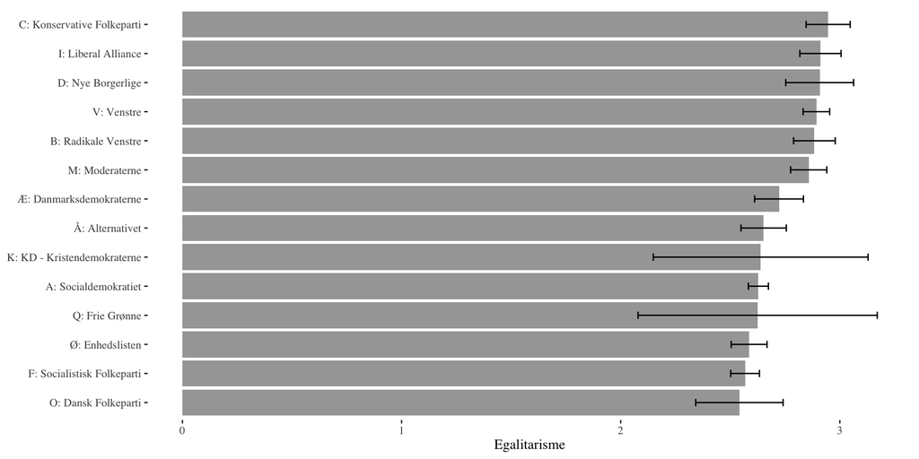

Indeksanalyse – egalitarisme og parti (95%-konfidensintervaller)

```r
vu_egal |>
  filter(parti22 %in% 1:29) |>
  group_by(parti22) |>
  summarise(egal_indeks_avg = mean(egal_indeks, na.rm = TRUE),
            egal_indeks_low = t.test(egal_indeks, na.rm = TRUE)$conf.int[1],
            egal_indeks_upp = t.test(egal_indeks, na.rm = TRUE)$conf.int[2]) |>
  ungroup() |>
  ggplot() +
  aes(x = fct_reorder(to_factor(parti22), egal_indeks_avg), y = egal_indeks_avg, ymin = egal_indeks_low, ymax = egal_indeks_upp) +
  geom_col(fill = "grey65") +
  geom_errorbar(width = .25) +
  ggthemes::theme_tufte() +
  labs(x = NULL, y = "Egalitarisme") +
  coord_flip()
```

## Konfidensintervaller I

> Et XX % konﬁdensinterval er det interval omkring et stikprøvemål [fx gns.] som ville indeholde populationsparameteren i XX % af gentagne stikprøver
- Konfidensintervaller defineres af **standardfejlen** og et valgt **konfidensniveau**  
  (udtrykkes i en *kritisk værdi*)
- Anvendes til at udtrykke, hvor *præcise* vores estimater er, og hvor meget vi bør stole på dem
  - I **hvilket interval** vi med rimelig sikkerhed kan finde den “sande” populationsværdi
- Ved tilstrækkeligt stort *n* (→ normalfordelt stikprøvemålsfordeling):
  - Konfidensintervallet (KI) for $\bar{Y}$: $\bar{Y} ± 1.96 × \hat{se}$,  
    hvor $\bar{Y}$ er stikprøvegennemsnittet, og *se* er standardfejlen

## Konfidensintervaller II

> Et XX % konﬁdensinterval er det interval omkring et stikprøvemål [fx gns.] som ville indeholde populationsparameteren i XX % af gentagne stikprøver
- Mere generelt er *KI* for $\bar{Y}$ givet ved $\bar{Y} ± z × \hat{se}$
- Den kritiske værdi, *z*, korresponderer til vores ønskede *konfidensniveau*
  - → jo større “sikkerhed”, desto bredere intervaller
- **95% er en konvention** → svarer til *alpha* = 0.05 (signifikansniveau)
  - 97,5% af normalfordelingen har en *z-værdi under 1.96*
  - 2,5% har en *z-værdi under -1.96*
  - = 95% har z-værdi mellem -1.96 og +1.96 (±2)
  - kan beregnes med `pnorm(1.96)` og `qnorm(0.975)`
- Alternative konfidensniveauer: 99% eller 90%

## Konﬁdensintervaller III

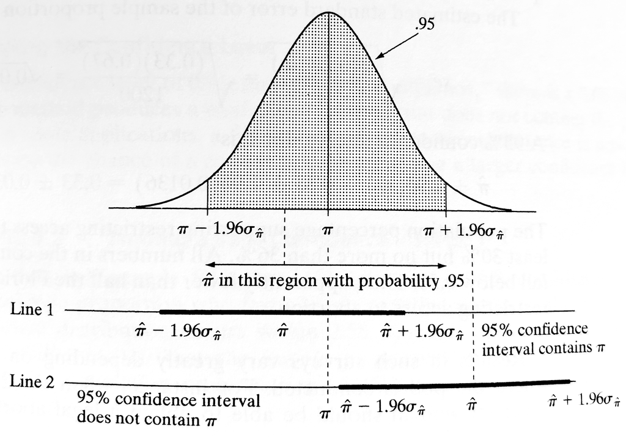

Kilde: Agresti & Finlay (2014), s. 111

## Konﬁdensintervaller III

- Vigtigt!
  - Konfidensintervallet giver *ikke* 95% sikkerhed for, hvad/hvor det sande gennemsnit er
  - Udtryk for (u)sikkerhed i sampling-*processen* – over tid
  - *Samplingfejl* – og ikke alle mulige andre slags fejl (fx manglende tilfældig udvælgelse)
  - Alligevel fortæller det meget om, hvad vi med rimelighed kan tro på:
    - “A **confidence interval** for a parameter is an interval of numbers within which the parameter is believed to fall …” (Agresti & Finlay 2014: 110)
- Interaktiv illustration: https://rpsychologist.com/d3/ci/

## Konﬁdensintervaller i R

- I praksis anvendes ofte en *t*-test: `t.test(var)`
- Antager *t-fordeling* frem for normalfordeling
  - generalisering af normalfordeling
  - minder enormt meget om
    - især ved stort *n* (konvergerer mod samme)
    - men har tykkere haler
  - *t* i stedet for z = 1.96 → lidt større (ved små *n*)
- **t-fordelingen fikser to problemer:**
  - lille *n* (hvor CLT ikke holder)
  - *s* frem for $\sigma$ (ekstra usikkerhed)
- Altid fint at bruge *t-test* til at beregne KI for gennemsnit (mv.)
  - samme logik og lignende resultater

## Konﬁdensintervaller i R

**Kode**

```r
t.test(sample5$alder)
```

```
    One Sample t-test

data:  sample5$alder
t = 17.024, df = 99, p-value < 2.2e-16
alternative hypothesis: true mean is not equal to 0
95 percent confidence interval:
 43.85173 55.42281
sample estimates:
mean of x
 49.63727
```

**Kode**

```r
# manuel udregning af KI, jf. standard-normalfordelingen
m <- mean(sample5$alder) # gns.
s <- sd(sample5$alder)   # std.avg.
n <- nrow(sample5)       # stikprøvestr.
se <- s / sqrt(n)        # standardfejl
ci_low  <- m - 1.96 * se  # KI nedre grænse
ci_high <- m + 1.96 * se  # KI øvre grænse

# vis gennemsnittet med konfidensintervallet i parantes
paste0(format(m, digits = 1, nsmall = 1), " [",
       format(ci_low, digits = 1, nsmall = 1), ", ",
       format(ci_high, digits = 1, nsmall = 1), "]")
## [1] "49.6 [43.9, 55.4]"
```

## Konﬁdensintervaller i R

**Kode**

```r
t.test(sample5$alder)
```

```
    One Sample t-test

data:  sample5$alder
t = 17.024, df = 99, p-value < 2.2e-16
alternative hypothesis: true mean is not equal to 0
95 percent confidence interval:
 43.85173 55.42281
sample estimates:
mean of x
 49.63727
```

## Note om standardfejl og konfidensintervaller

- Der findes andre måder at beregne *standardfejl*
- Der findes også andre *kritiske værdier* end z = 1.96
- *Husk det* (så kan man lære detaljerne løbende efter behov)
- De absolut vigtigste er dem, der følger *normalfordelingen/t-fordelingen*
- I praksis får man R til at beregne
- I får lige en enkelt *alternativ formel for standardfejl* med:

## Standardfejlen for en andel

- Andel → binær variabel
  - fx meningsmåling/partivalg (fx 20% Soc.Dem.)
- *X “succeser” ud af N mulige* (N = stikprøvestørrelse/forsøg)
  - følger binomialfordelingen
- $\hat{se}_{andel} = \sqrt{\frac{p × (1 - p)}{n}}$, hvor *p* er *andelen* (gns.), og *n* er stikprøvestørrelsen
  - fx *p* = 20%, *n* = 100 → $\hat{se}_{andel} = \sqrt{\frac{0.2 × 0.8}{100} = 0.04}$
  - obs! *s* (variansen) er slet ikke med i formlen for $\hat{se}_{andel}$
- Ved stort nok N, er konfidensintervallet stadig: $\bar{Y} ± 1.96 × \hat{se}_{andel}$
  - resultater næsten ækvivalente med `t.test(var)` → prøv selv

## Opsummering

- Sandsynlighed(sfordelinger)
- Normalfordelingen og z-værdier
- Stikprøver, gennemsnit og stikprøvemålsfordelinger
- Den *Centrale Grænseværdisætning* (CLT):
  - vi kender ikke fordelingen i populationen, men vi ved, hvad vi kan forvente af (sampling)usikkerhed i *gennemsnit mv. i stikprøven*
  - konkret er **stikprøvemålsfordelingen altid normalfordelt**, når bare *n* er højt (CLT)
  - gælder selvom selve variablen *ikke* er normalfordelt (evt. langt fra!)
  - bruges til at kvantificere usikkerheden i vores estimater, når vi *infererer* fra data til populationen
- **Standardfejl (gns.):** $\hat{se} = \frac {s} {\sqrt{n}}$
- **95%-konﬁdensintervaller:** $\bar{Y} ± 1.96 × \hat{se}$

## Næste tre uger

- Bygger direkte ovenpå
- Silje Hermansen
  - Hypoteser og signifikans
  - Bivariate analyser
- **Påske**
- Overlap i **statistik-temaerne** – også efter påske
  - *statistisk signifikans*, p-værdier, konfidensintervaller, hypotesetest, korrelation, estimation etc.
  - men det skader ikke :)